# Analysis of the damping and delay in aially symmetric setting

@TO 2023-12-18

The analysis in thisnotebook was inpsired by a question by Toine Vergroesen regarding the signal in the groundwater caused by a fluctuaiton of the water level in the Quarry Lakes in Fremont (Ca). The head at about 1 km from the lakes in both the first and the second aquifer fluctuated simmilar to the water level in the lakes, however the fluctations in the second, deeper, aquifer was larger than that in the first aquifer. The contention was that the lakes did nog penetrate through the aquitard between the two aquifers. The question posed was, how it is possible that the amplitude of the fluctuation of the head in the second aquifer is greater than that in the first aquifer, which seems to contradict intuition.

The registered time sries show that the signals are related, yet the groundwater head signals are damped and delayed, as to be expected. The best way to show this is to overlap the graphs of the signals by compressing the vertical scale of the lake level time series with respect to that of the groundwater head to find the damping of the lake signal upon arrival at the observation wells at 100o m, and to shift the graphs along the time axis to estimate the delay with respect of the stage of the Lakes.

Before this can be done, the groundwater head times series head first to be shifted vertically such that the average heads matched the average lake levels. This procedure works in this case as the time series show that the lakes stage is more or less periodical with a cycle time of one year and, therefore, may be approximated by a corresponding sine wave, which is altered downstream by damping and delay only, while, the frequency, of course, does not change.

That the head in the two aquifers is way below the stage of the lakes, can be attributed to a further unknown yet more or less contant in time background extraction in the Fremont area. Such an extraction does not alter the analysis, as lnng as it can be considered constant in time on the scales of interest, which seems to be the case.

### Concrete values of the Quarry Lakes

The average head in the first aquifer 4 km from the lakes it has declined further to 9.5 ft. This point will not be analyzed by lack of the original data.

The damping factor is obtained from the ratio of the vertical axis in the Lakes srtage and the same distance on the shrinked vertical axis of the head in WVP1, (20-10) / (34 - 16) = 0.56.

The delay is obtained by comparing the vaues of the horizontal axis for the same point in the overlapped graphs. This way, delay in the first aquifer relative to the lakes is about 33 days. The delay of the head in the second aquifer at 1 km from the lakes is approximately 5 days. Notice that the accuracy of this latter delay is limited due to the small time scales of the available graphs.

The small delay in the second aquifer relative to that in first aquifer must be due to is due to a much lower storativity in the confined layer and, to a smaller part, to its probably lower transmissivity.

## Analytical analysis of the damping and delay

The the damping and delay of the Lakes signal in non=leaky aquifers can be analyzed analytically ussing the analytical solution for a sine-like discharge fluctuation in well, i.e. in an axially symmetric context. The combined Quarry Lakes can be considered more or less circular. However, we may have to also consider the effect of a nearby impermeable wall that is formed by the mountain range adjaced to the San Francisco Bay running North-South close to the east of the lakes. We may, therefore, either consider the lakes as a half-circle cut by this impervious wall or consider the combined lakes as circular and take into account a mirror circular lake opposite of the imppervious mountain face. For this simplified analysis, it suffices to consider the lakes a half-circle, such that the context is axially symmetric.

$$ \phi(r, t) = \frac{Q_0}{2 \pi kD}\Im\left[e^{i \omega t}K_0\left(\beta r \sqrt{i \omega}\right)\right],\,\,\,\,\beta^2=\frac S {kD}$$

This fromula uses complex numbers to represent the regular fluctuation. It can be described by an envelope, which is the amplitude as a function of $r$ and by a delay, also a fucntion of $r$. The envelope then is $$ \Phi(r) = \frac{Q_0}{2 \pi kD} \left|K_0(\beta r \sqrt{i \omega})\right| = \frac{Q_0}{2 \pi kD} K_0\left(\beta r \sqrt{\omega}\right) $$ and the delay is $$ T_{delay}(r) = \frac{\angle\left[K_0\left(\beta r \sqrt{\omega}\right)\right]}{\omega} $$

The damping of the amplitude may be compared to the steationary solution of flow to a well in a semi-confined aquifer by writing $$ \frac{r}{\lambda} = \beta r \sqrt{\omega} = r \sqrt{\frac{\omega S}{kD}} $$

So that we may defined a characteristic of spreading length $\lambda$ equal to $$ \lambda = \sqrt{\frac{kD}{\omega S}}$$

# Coding

```python
import numpy as np
import matplotlib.pyplot as plt
from scipy.special import kv as Kv, k0 as K0
import pandas as pd
# from etc import newfig   # Heb ik n u in deze notebook gekopieerd
```

```python
def newfig(title='title?', xlabel='xlabel?', ylabel='ylabel?',
           xscale=None, yscale=None, xlim=None, ylim=None,
           figsize=(12, 8), fontsize=12, aspect=None, invert_yaxis=False):
    """Return a new figure.

    Parameters
    ----------
    title, xlabel, ylabel: str
        title of fig and of xaxis and yaxis
    xscale: str ('log', 'linear') or None
        type of axis
    yscale: str ('log', 'linear') or None
        type of axis
    figsize: 2-tuple
        fig_size in inches
    fontsize: int
        fontsize in points of titles
    """
    fig, ax = plt.subplots()
    fig.set_size_inches(figsize)
    ax.set_title(title)
    ax.set_xlabel(xlabel)
    ax.set_ylabel(ylabel)
    if xscale: ax.set_xscale(xscale)
    if yscale: ax.set_yscale(yscale)
    if xlim is not None: ax.set_xlim(xlim)
    if ylim is not None: ax.set_ylim(ylim)
    if aspect: ax.set_aspect(aspect)

    if fontsize:
        for item in ([ax.title, ax.xaxis.label, ax.yaxis.label] +
                        ax.get_xticklabels() + ax.get_yticklabels()):
            item.set_fontsize(fontsize)

    if invert_yaxis:
        ax.invert_yaxis()

    ax.grid()
    return ax
```

```python
S = 0.1  # [-]
kD = 500 # [m2/d]
omega = 2 * np.pi / 365 # [rad/day]
```

### Spreding or characteristic length $\lambda$ of the dynamice axial symmetric system as a functio of storage coefficient $S$

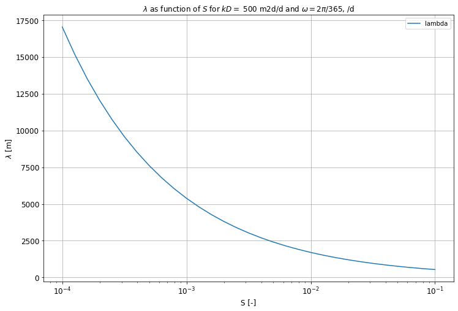

```python
S = np.logspace(-4, -1, 31)

ax = newfig(r"$\lambda$ as function of $S$ for $kD =$ {} m2d/d and $\omega = 2\pi/365$, /d".format(kD),
            'S [-]', r'$\lambda$ [m]', xscale='log', yscale='linear')
L = np.sqrt(kD / omega / S)
ax.plot(S, L, label='lambda')
ax.legend()
```

### Envelope $ K_0(\beta r \sqrt{\omega}) $ for different storage coefficients.

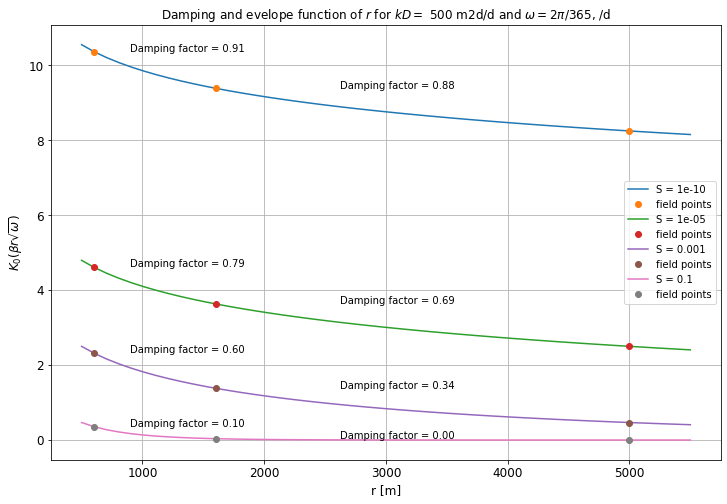

```python
ax = newfig(r"Damping and evelope function of $r$ for $kD =$ {} m2d/d and $\omega = 2\pi/365$, /d".format(kD),
            'r [m]', r'$K_0(\beta r \sqrt{\omega})$', xscale='linear')

r = np.linspace(500, 5500, 50)

rp  = np.array([600., 1600., 5000.])  # Lakes face, first obs well 1000 m from lakes, second obs well 4200 m from lakes

def k0(beta, r, omega):
    return K0(beta * r * np.sqrt(omega))

for S in [1e-10, 1e-5, 1e-3, 1e-1]:
    beta = np.sqrt(S/ kD)
    ax.plot(r, k0(beta, r, omega), label='S = {:.5g}'.format(S))
    ax.plot(rp, k0(beta, rp, omega), 'o', label='field points')
    henv = k0(beta, rp, omega)
    damping = henv[1:] / henv[:-1]

    yp = k0(beta, rp, omega)
    for r_, dr, y_, d_ in zip(rp[:-1], np.diff(rp), yp, damping):

        ax.text(r_ + 0.3 * dr, y_, 'Damping factor = {:.2f}'.format(d_))

ax.legend()
```

### $ T_{delay} = \frac{\angle\left[K_0(\beta r \sqrt{i \omega}\right]}{\omega} $ for different storage coefficients

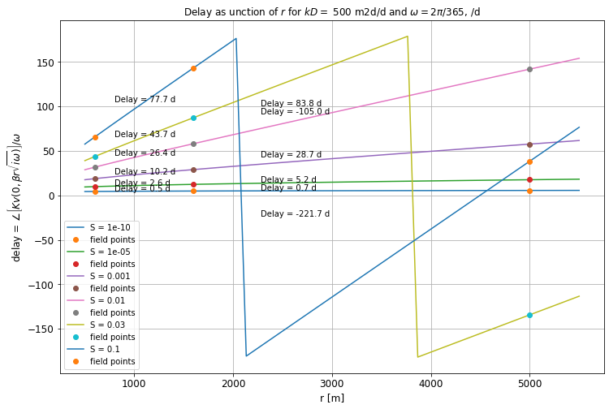

```python
# Use same kD and omega as before.

def delay(beta, r, omega):
    return -np.angle(Kv(0, beta * r * np.sqrt(1j * omega))) / omega

ax = newfig(r"Delay as unction of $r$ for $kD =$ {} m2d/d and $\omega = 2\pi/365$, /d".format(kD),
            xlabel='r [m]',
            ylabel=r'delay = $\angle \left[Kv(0, \beta r \sqrt{i \omega}) \right] / \omega$',
            xscale='linear')

r  = np.linspace(500, 5500, 50)

rp  = np.array([600., 1600., 5000.])  # Lakes face, first obs well 1000 m from lakes, second obs well 4200 m from lakes

for S in [1e-10, 1e-5, 1e-3, 1e-2, 0.03, 1e-1]:
    beta = np.sqrt(S/ kD)
    ax.plot(r,  delay(beta, r,  omega), label='S = {:.5g}'.format(S))
    ax.plot(rp, delay(beta, rp, omega), 'o', label='field points')
    dt = np.diff(delay(beta, rp, omega))

    yp = 0.5 * (delay(beta, rp[:-1], omega) + delay(beta, rp[1:], omega))
    for r_, dr, y_, dt_ in zip(rp[:-1], np.diff(rp), yp, dt):

        ax.text(r_ + 0.2 * dr, y_, 'Delay = {:.1f} d'.format(dt_))

ax.legend()
```

## Damping factor $F_d$ relative to lake fluctuation as a funciton of $r$, i.e. $F_d = Env(r) / Env(r_{Lakes})$

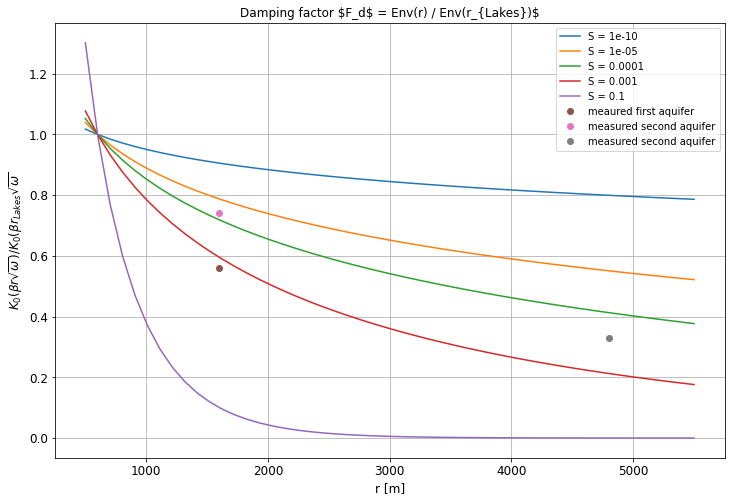

```python
ax = newfig(r"Damping factor $F_d$ = Env(r) / Env(r_{Lakes})$",
            'r [m]', r'$K_0(\beta r \sqrt{\omega}) / K_0(\beta r_{Lakes} \sqrt{\omega} $', xscale='linear')

r = np.linspace(500, 5500, 50)

rLakes  = 600 # m
rObs1, yObs11, yObs12 = rLakes + 1000, 0.56, 0.74
rObs2, yObs21, yObs22 = rLakes + 4200, 0.33, np.nan

def k0(beta, r, omega):
    return K0(beta * r * np.sqrt(omega))

for S in [1e-10, 1e-5, 1e-4, 1e-3, 1e-1]:
    beta = np.sqrt(S/ kD)
    ax.plot(r, k0(beta, r, omega) / k0(beta, rLakes, omega), label='S = {:.5g}'.format(S))

ax.plot(rObs1, yObs11, 'o', label='meaured first aquifer')
ax.plot(rObs1, yObs12, 'o', label='measured second aquifer')
ax.plot(rObs2, yObs21, 'o', label='measured second aquifer')

ax.legend()
```

## Delay relative to Lake stage

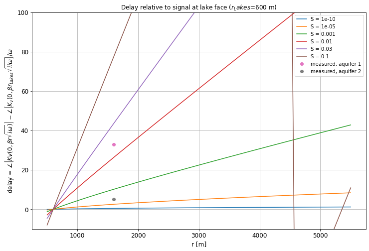

```python
# Use same kD and omega as before.

def delay(beta, r, omega):
    tdelay = -np.angle(Kv(0, beta * r * np.sqrt(1j * omega))) / omega
    if np.isscalar(tdelay):
        if tdelay < 0:
            tdelay += 2 * np.pi / omega
    else:
        tdelay[tdelay < 0] += 2 * np.pi / omega
    return tdelay

ax = newfig(r"Delay relative to signal at lake face ($r_Lakes$=600 m)".format(kD),
            xlabel='r [m]',
            ylabel=r'delay = $\angle \left[Kv(0, \beta r \sqrt{i \omega}) \right] - \angle\left[K_v(0, \beta r_{Lakes} \sqrt{ii \omega}\right] / \omega$',
            xscale='linear',
            ylim=(-10, 100))

rLakes = 600
r  = np.linspace(500, 5500, 50)

rObs1, tdObs11, tdObs12  = rLakes + 1000, 33, 5

for S in [1e-10, 1e-5, 1e-3, 1e-2, 0.03, 1e-1]:
    beta = np.sqrt(S/ kD)
    ax.plot(r,  delay(beta, r,  omega) - delay(beta, rLakes, omega), label='S = {:.5g}'.format(S))

ax.plot(rObs1, tdObs11, 'o', label='measured, aquifer 1')
ax.plot(rObs1, tdObs12, 'o', label='measured, aquifer 2')

ax.legend()
```

## Show the stage of the lakes and the head in the two aquifers at 1000 m from the lakes

Rhia shows the amplitude and the delay at $r_{Lakes}=600$ and $r_{Obs}=1600$ m for different $S$.

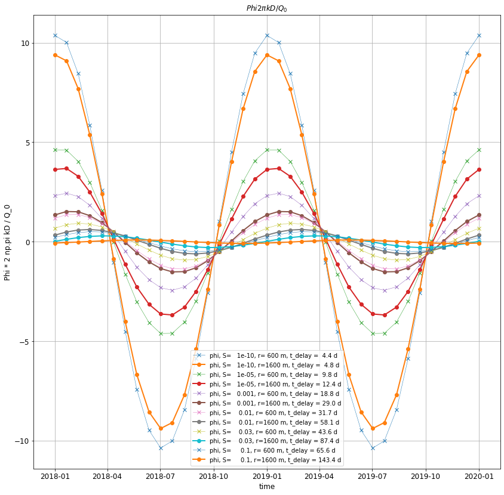

```python
# Use same kD and omega as before

start_date = '2018-01-01'
t = np.linspace(0, 2 * 365, 37)
dt = np.datetime64(start_date) + t * np.timedelta64(1, 'D')

rLakes = 600
rObs   = rLakes + 1000


def kv(beta, r, omega):
    return Kv(0, beta * r * np.sqrt(1j * omega))

def brug230(t, beta, r, omega):
    return np.exp(1j * omega * t) * kv(beta, r, omega)

ax = newfig(r'$Phi 2 \pi kD / Q_0$', 'time', 'Phi * 2 np.pi kD / Q_0', figsize=(14, 14) )

for S in [1e-10, 1e-5, 1e-3, 1e-2, 0.03, 1e-1]:
    beta = np.sqrt(S / kD)

    for r, ls, lw in zip([rLakes, rObs], ['x-', 'o-'], [0.5, 2]):
        phi = brug230(t, beta, r, omega)
        tdelay = -np.angle(phi[0]) / omega

        ax.plot(dt, np.real(phi), ls, linewidth=lw, label='phi, S={:8.4g}, r={:4.0f} m, t_delay = {:4.1f} d'.format(S, r, tdelay))

ax.legend()
plt.show()
```

## Verify that $K_0(x)$ and $K_v(0, z)$ are the same for $z$ is real (not complex)

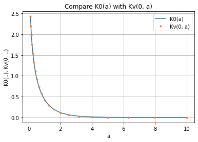

```python
fig, ax = plt.subplots()

ax.set_title("Compare K0(a) with Kv(0, a)")
ax.set_xlabel('a')
ax.set_ylabel('K0(..), Kv(0, ..)')
ax.grid(True)
a = np.logspace(-1, 1, 21)
ax.plot(a, K0(a), label='K0(a)')
ax.plot(a, Kv(0, a), '.', label='Kv(0, a)')
ax.legend()
plt.show()
```

The dimensionless envelope of he head $\Phi(r)$ as a function of $r$ is given by

$$ \Phi(r) \frac{2 \pi kD}{Q_0} = \left| K_0\left(\beta r \sqrt{i \omega}\right) \right| $$

and the delay by

$$ T_{delay}(r) = \frac{\angle\left[K_0\left(\beta r \sqrt{i \omega}\right)\right]}{\omega} $$

both of which can be readily computed for any concrete situation.

# Complex numbers and their exponential form

A complex number $z = $a + ib = r e^{i\theta}$ has

$$ a = \Re(z), \,\,\,\ b = \Im(z)$$$$ r = \left|z\right| $$$$ \theta = \angle\left(z\right)$$

Angle $\theta$ will always be returned such that $-\pi <= \theta <= +\pi$.

$$z = a + i b = r e^{i \theta} = \left|z \right| e^{i \,\, angle(z)} $$